# HBCU Enrollment

```r
library(tidyverse)
hbcu_all <- readr::read_csv('https://raw.githubusercontent.com/rfordatascience/tidytuesday/master/data/2021/2021-02-02/hbcu_all.csv')
```

This week’s data is on Historically Black Colleges and Universities, their enrollment and attendance. This data actually only contains data on total enrollment for HBCUs for some year range. Let’s see the skim.

```r
skimr::skim(hbcu)
```

```
-- Data Summary ------------------------
                           Values
Name                       hbcu
Number of rows             32
Number of columns          12
_______________________
Column type frequency:
  numeric                  12
________________________
Group variables            None

-- Variable type: numeric ------------------------------------
# A tibble: 12 x 11
   skim_variable    n_missing complete_rate    mean      sd
 * <chr>                <int>         <dbl>   <dbl>   <dbl>
 1 year                     0             1   1999.    10.6
 2 total_enrollment         0             1 281566. 31160.
 3 males                    0             1 113355.  7608.
 4 females                  0             1 168211  24104.
 5 x4_year                  0             1 254156. 22659.
 6 x2_year                  0             1  27411.  9947.
 7 total_public             0             1 208626. 27023.
 8 x4_year_public           0             1 182113. 17698.
 9 x2_year_public           0             1  26513. 10582.
10 total_private            0             1  72940.  5009.
11 x4_year_private          0             1  72043.  5550.
12 x2_year_private          0             1    898.   713.
       p0     p25     p50     p75   p100 hist
 *  <dbl>   <dbl>   <dbl>   <dbl>  <dbl> <chr>
 1   1976   1992.   2000.   2007.   2015 ▃▅▇▇▇
 2 222613 269293  281464. 307239. 326614 ▅▁▇▃▇
 3  97523 107839. 114314  118696. 127437 ▂▇▆▇▅
 4 117944 161450. 166988. 189176. 199177 ▃▁▇▂▇
 5 206676 248913. 259703  272692  283099 ▃▁▅▆▇
 6  14675  18150.  25068.  37102.  43515 ▇▂▁▃▃
 7 156836 197054. 207358. 231836  249146 ▅▁▇▃▆
 8 143528 175167. 186088. 197069. 205774 ▃▁▃▇▇
 9  12827  16528   24392.  36824   43372 ▇▃▁▃▅
10  61227  71476   74381   76032.  80608 ▂▂▃▇▅
11  59600  70750   73264.  75629.  79837 ▃▁▂▇▅
12     93    306.    708.   1474.   2629 ▇▅▃▂▁
```

The data is very small, 32 observations of 12 variables. Every variable read in as numeric. There are no missing values. The range of years is from 1976 to 2015, with data every 4 years from 1976-1980, every 2 years from 1980-1990, and every year thereafter.

For once, the histograms are useful. You can see that there are fewer observations for the older years. Total enrollment, number of females, and total public enrollment are similarly and unusually distributed; I’ll look into these. `x4_year` is left-skewed; `x2_year_private` is right skewed, both fairly evenly. `x2_year_public` is weighted on its tails, and number of males is almost normal in its distribution.

The data is temporal, so here are all the variables over time.

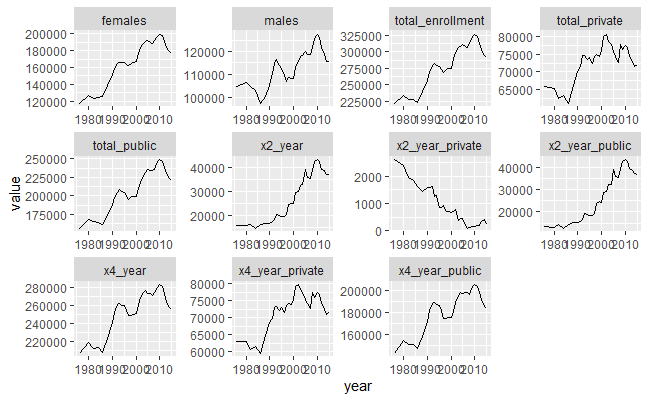

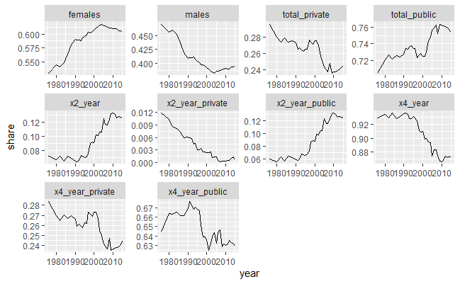

So females are on the rise, with a consequent fall in male enrollment. Public outweighs private, and this trend seems to be getting stronger. A fall in 4-year (thoroughly dominant, still) is complemented with a rise in 2-year. In the final four categories (types of two- and four-year), While 4-year public dominant, it has fallen a little since the 90s. I’d like to see relative area charts of these.

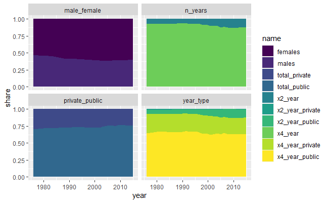

Many of these trends are consistent, which means it might be okay to do a slope chart. I like slope charts – they look good and they simplify the shape of the trendline. They only make sense under certain circumstances, though, and I’m not sure if this data meets those. Let’s make one anyway.

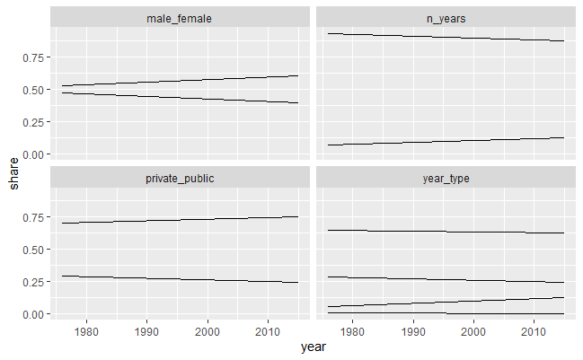

Not so good looking. Moving on then. Maybe a four-panel composition like I have above could work, but not by itself. It needs a focus. One of the 3-panel SMCP-style designs could work.

Possible features:

- Total enrollment over time
- Relative enrollment of different types as 4-panel
- Map showing the locations of HBCUs

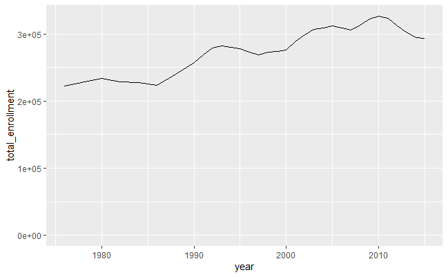

This isn’t a very good centerpiece, but neither are the panels. The map is an idea, I suppose, but it’s a stretch. Not to mention it’s going to take some time to get the data together.

Well, I’m scrapping the idea I had before. I just don’t have the time or design skills to execute a larger graphic in so short a time. I need a way into this data, but I don’t know what it is. I’m feeling impatient this week, which is a problem. There are a few other things I would rather be doing. Keep it simple, then.